# Untitled

Max Lemes

8/31/2021

# Introdução

Entendemos a **Estatística** como o conjunto de técnicas que permite, de forma sistemática, organizar, descrever, analisar e interpretar dados oriundos de estudos ou experimentos, realizados em qualquer área do conhecimento.

# A Estatística se divide em 3 áreas

1. Estatítica Descritiva;
2. Probabilidade;
3. Inferência Estatística.

# Estatítica Descritiva

A estatística descritiva é a etapa inicial da análise utilizada para descrever e resumir os dados. O objetivo básico da estatística descritiva é o de sintetizar uma série de valores de mesma natureza, permitindo dessa forma que se tenha uma visão global da variação desses valores, organiza e descreve os dados de três maneiras: por meio de tabelas, de gráficos e de medidas descritivas.

# Probabilidade

A Probabilidade é uma teoria matemática utilizada para se estudar a incerteza oriunda de fenomênos de carácter aleatório.

# Inferência Estatística

É o estudo de técnicas que possibilitam a extrapolação, a um grande conjunto de dados, das informações e conclusões obtidas a partir de subconjuntos de valores usualmente de dimensão muito menor.

# População e Amostra

Na terminologia estatística o conjunto de dados que contém as caraterísticas de interesse, é chamado de população. Tendo em vista as dificuldades de se obter ou analisar os dados de toda a **população**, toma-se um subconjunto da mesma o qual é denominado **amostra**.

# Tipos de Amostras

1. **Amostra casual simples**: seleciona os itens ao acaso;
2. **Amostra estratificada**: seleciona os dados a fim de manter as proporções da população.
3. **Amostra sistemática**: seleciona os itens de forma pré determinada, de 5 em 5 ou de 10 em 10.
4. **Amostra por conglomerados**: selciona os itens aleatoriamente dentro de grupos;
5. **Amostra por conveniência**: seleciona os itens por conveniência (disponibilidade dos mesmos) e não por algum critério estatístico.

# Teoria da Amostragem

Estuda esses e outros tipos de amostra além de determinar o tipo e o tamanho de cada amostra de acordo com o tipo de dados e a confiabilidade desejada.

# Exemplo de um Pie Plot

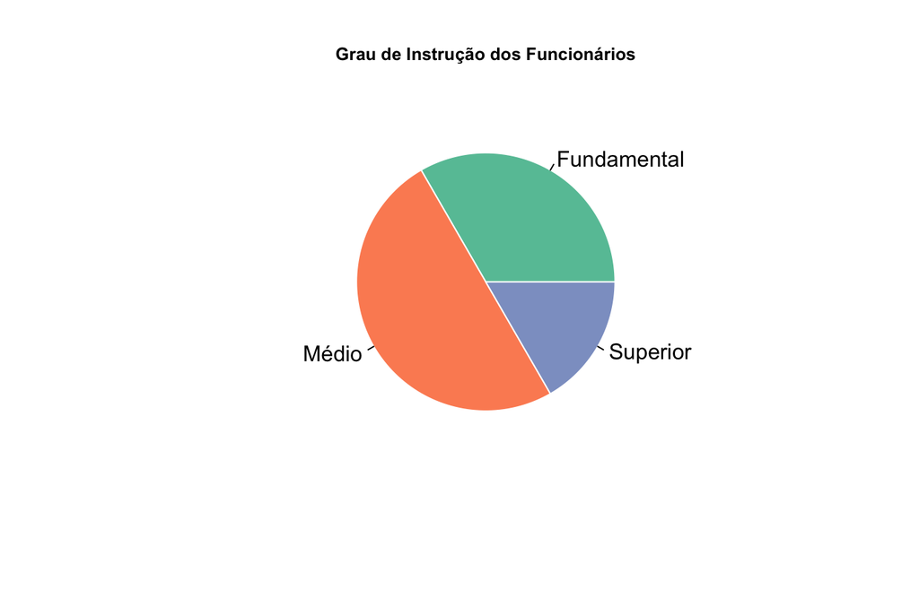

# Exemplo de um Scatter Plot

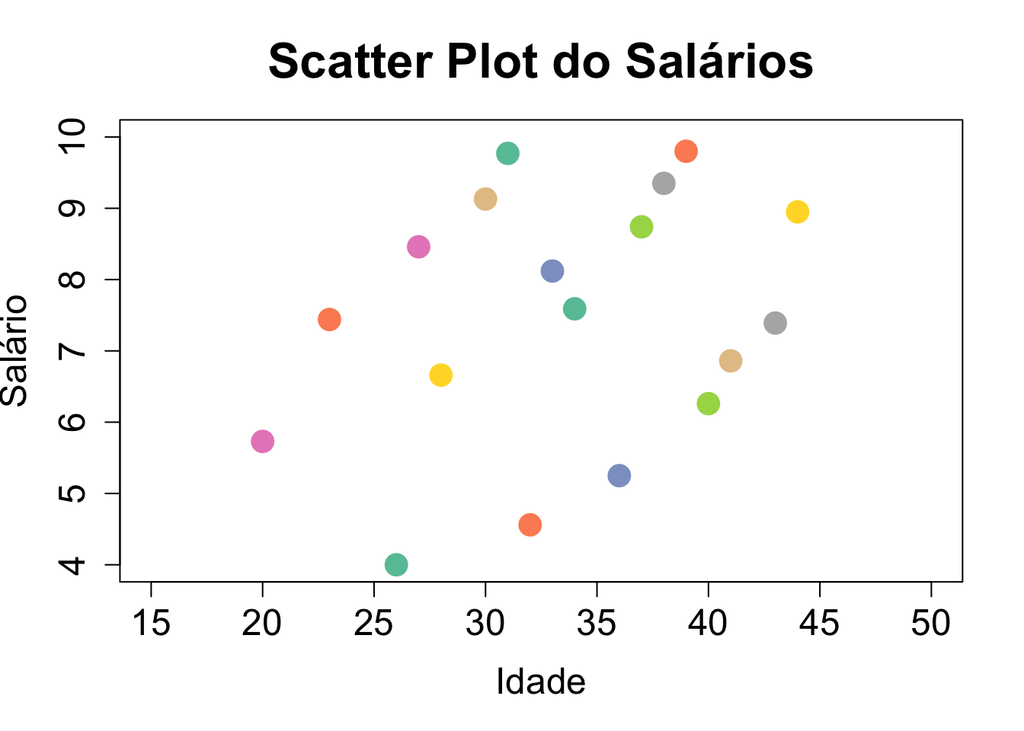

# Exemplo de um Histograma

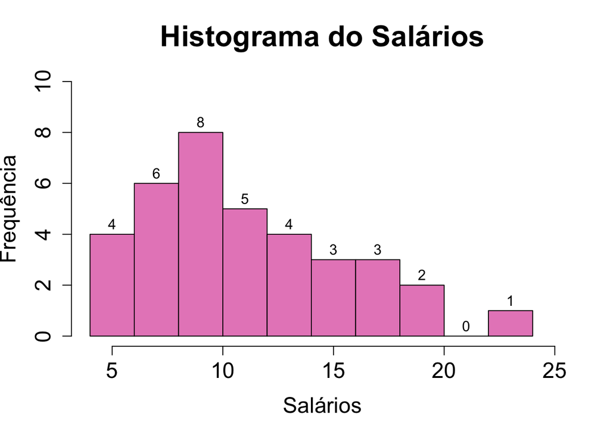

# Exemplo de um BoxPlot

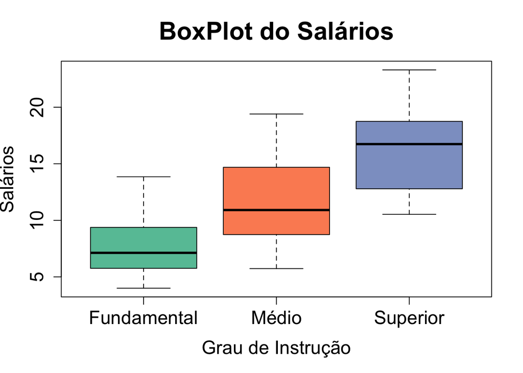

# Exercício

# Solução

# a) Vamos fazer um gráfico de dispersão

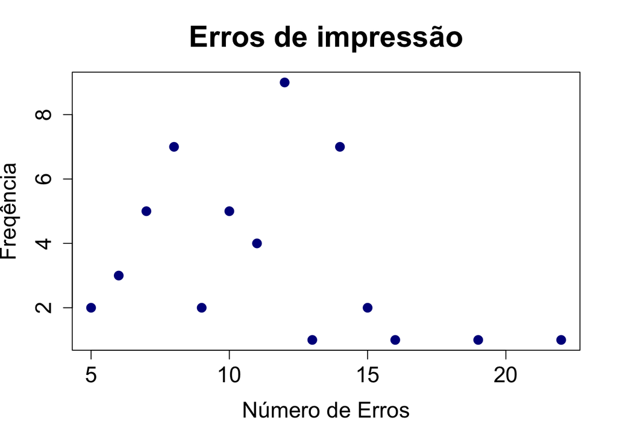

# b) O Histograma fica assim

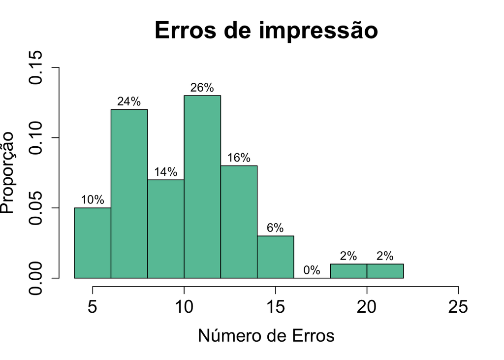